# COMP-456_FP1

Eric Wang

2022-09-15

## Research Questions

- How water scarcity may make an impact on a corporate’s financial performance (e.g. bonds)?
- How does climate change impact agriculture and food prices?
- Will climate change affect global trade (eg. import of necessities)?

```r
library(tidyverse)
```

```r
library(ggplot2)
library(rworldmap)
library(maps)
library(ggmap)
library(ggthemes)

theme_set(theme_minimal())
```

## 1. Data Set 1: World Food Price

```r
food_price = read_csv("data/wfpvam_foodprices.csv")
food_price
```

```
## # A tibble: 2,050,638 × 18
##    adm0_id adm0_name   adm1_id adm1_name  mkt_id mkt_name cm_id cm_name   cur_id
##      <dbl> <chr>         <dbl> <chr>       <dbl> <chr>    <dbl> <chr>      <dbl>
##  1       1 Afghanistan     272 Badakhshan    266 Fayzabad    55 Bread - …      0
##  2       1 Afghanistan     272 Badakhshan    266 Fayzabad    55 Bread - …      0
##  3       1 Afghanistan     272 Badakhshan    266 Fayzabad    55 Bread - …      0
##  4       1 Afghanistan     272 Badakhshan    266 Fayzabad    55 Bread - …      0
##  5       1 Afghanistan     272 Badakhshan    266 Fayzabad    55 Bread - …      0
##  6       1 Afghanistan     272 Badakhshan    266 Fayzabad    55 Bread - …      0
##  7       1 Afghanistan     272 Badakhshan    266 Fayzabad    55 Bread - …      0
##  8       1 Afghanistan     272 Badakhshan    266 Fayzabad    55 Bread - …      0
##  9       1 Afghanistan     272 Badakhshan    266 Fayzabad    55 Bread - …      0
## 10       1 Afghanistan     272 Badakhshan    266 Fayzabad    55 Bread - …      0
## # … with 2,050,628 more rows, and 9 more variables: cur_name <chr>,
## #   pt_id <dbl>, pt_name <chr>, um_id <dbl>, um_name <chr>, mp_month <dbl>,
## #   mp_year <dbl>, mp_price <dbl>, mp_commoditysource <lgl>
```

### a. Data source

Compiled by the World Food Program and distributed by HDX. [Link](https://www.kaggle.com/datasets/lasaljaywardena/global-food-prices-datasets)

### c. Data limitations

The data’s biggest problem is that it only contains food prices for developing countries. That will be a problem if we are going to analyze it on a global scale.

### d. Variable names

```r
names(food_price)
```

```
##  [1] "adm0_id"            "adm0_name"          "adm1_id"
##  [4] "adm1_name"          "mkt_id"             "mkt_name"
##  [7] "cm_id"              "cm_name"            "cur_id"
## [10] "cur_name"           "pt_id"              "pt_name"
## [13] "um_id"              "um_name"            "mp_month"
## [16] "mp_year"            "mp_price"           "mp_commoditysource"
```

### e. Visualization

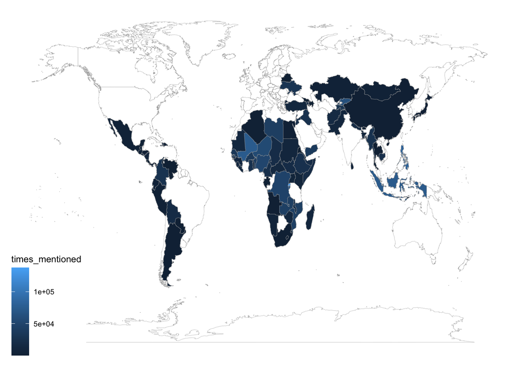

```r
world_map <- map_data("world")

food_price %>%
  group_by(adm0_name) %>%
  summarize(times_mentioned = n()) %>%
  ggplot() +
  geom_map(dat = world_map,
           map = world_map,
           aes(map_id = region),
           fill="white",
           color="dark grey",
           size = 0.1) +
  geom_map(map = world_map,
           aes(map_id = adm0_name,
               fill = times_mentioned),
           color = "dark grey",
           size = 0.1) +
  expand_limits(x = world_map$long, y = world_map$lat) +
  theme_map()
```

## 2. Data Set 2:

```r
disasters = read_csv("data/disasters.csv")
disasters
```

```
## # A tibble: 16,126 × 45
##     Year Seq   Glide `Disaster Group` `Disaster Subgroup` `Disaster Type`
##    <dbl> <chr> <chr> <chr>            <chr>               <chr>
##  1  1900 9002  <NA>  Natural          Climatological      Drought
##  2  1900 9001  <NA>  Natural          Climatological      Drought
##  3  1902 0012  <NA>  Natural          Geophysical         Earthquake
##  4  1902 0003  <NA>  Natural          Geophysical         Volcanic activity
##  5  1902 0010  <NA>  Natural          Geophysical         Volcanic activity
##  6  1903 0006  <NA>  Natural          Geophysical         Mass movement (dry)
##  7  1903 0012  <NA>  Natural          Geophysical         Volcanic activity
##  8  1904 0003  <NA>  Natural          Meteorological      Storm
##  9  1905 0005  <NA>  Natural          Geophysical         Mass movement (dry)
## 10  1905 0003  <NA>  Natural          Geophysical         Earthquake
## # … with 16,116 more rows, and 39 more variables: Disaster Subtype <chr>,
## #   Disaster Subsubtype <chr>, Event Name <chr>, Country <chr>, ISO <chr>,
## #   Region <chr>, Continent <chr>, Location <chr>, Origin <chr>,
## #   Associated Dis <chr>, Associated Dis2 <chr>, OFDA Response <chr>,
## #   Appeal <chr>, Declaration <chr>, Aid Contribution <dbl>,
## #   Dis Mag Value <dbl>, Dis Mag Scale <chr>, Latitude <chr>, Longitude <chr>,
## #   Local Time <chr>, River Basin <chr>, Start Year <dbl>, Start Month <dbl>, …
```

### b. Data description

Natural disasters of all countries from 1900 to 2021.

### c. Data limitations

Although this dataset is very detailed, there are a lot of missing values.

### d. Variable names

```r
names(disasters)
```

```
##  [1] "Year"                       "Seq"
##  [3] "Glide"                      "Disaster Group"
##  [5] "Disaster Subgroup"          "Disaster Type"
##  [7] "Disaster Subtype"           "Disaster Subsubtype"
##  [9] "Event Name"                 "Country"
## [11] "ISO"                        "Region"
## [13] "Continent"                  "Location"
## [15] "Origin"                     "Associated Dis"
## [17] "Associated Dis2"            "OFDA Response"
## [19] "Appeal"                     "Declaration"
## [21] "Aid Contribution"           "Dis Mag Value"
## [23] "Dis Mag Scale"              "Latitude"
## [25] "Longitude"                  "Local Time"
## [27] "River Basin"                "Start Year"
## [29] "Start Month"                "Start Day"
## [31] "End Year"                   "End Month"
## [33] "End Day"                    "Total Deaths"
## [35] "No Injured"                 "No Affected"
## [37] "No Homeless"                "Total Affected"
## [39] "Insured Damages ('000 US$)" "Total Damages ('000 US$)"
## [41] "CPI"                        "Adm Level"
## [43] "Admin1 Code"                "Admin2 Code"
## [45] "Geo Locations"
```

There are many critical variables in this dataset, such as `Start Year`, `End Year`, `Country`, `Disaster Type`, and so on. I calculated the number of natural disasters in different countries from 1990 to 2021 based on `Year` and `Country` variables

### e. Visualization

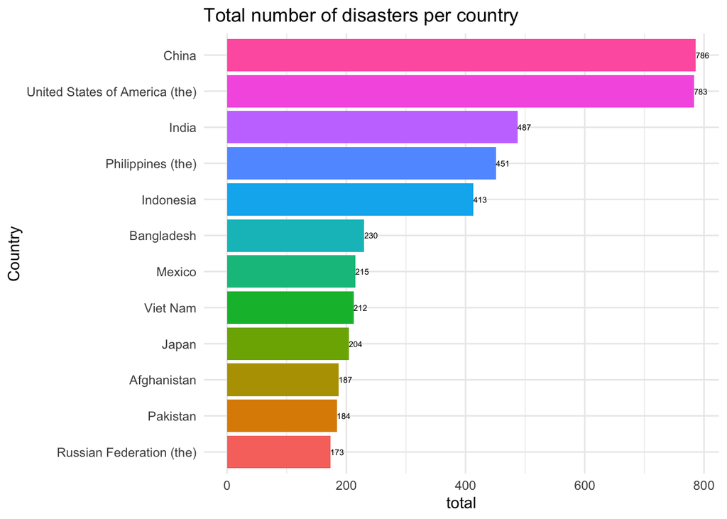

```r
df <- disasters %>%
  filter(Year >= 1990) %>%
  group_by(Country) %>%
  summarise(total = n()) %>%
  arrange(desc(total)) %>%
  filter(total >= 173)

df %>%
  mutate(Country = reorder(Country, total)) %>%
  ggplot(aes(x = Country,
             y = total,
             fill = Country)) +
  geom_bar(stat = "identity")+
  coord_flip()+
  geom_text(aes(label=total), hjust=0, size=2)+
  guides(fill="none")+
  ggtitle("Total number of disasters per country")
```

### 3. Data Connection

Country information and time information can link the two datasets together. We can investigate whether natural disasters affect crop yields and, thus, food prices.